# GAMMs for LVC workshop

28th February 2025

# Data and Setup

```r
data_workshop <- read_csv("../data/data_workshop.csv")
```

Convert factors to ordered factors and set contrasts to “contr.treatment” (Soskuthy, 2017, p.24)

```r
data_gamm <- data_workshop %>%
  mutate_if(is.character,as.factor) %>%
  filter(lexSet == "GOAT") %>% # so we only look at one lexical set
  mutate(ageGroup_ord = ordered(ageGroup)) %>%
  mutate(folSeg_ord = ordered(folSeg)) %>%
  mutate(medium_ord = ordered(medium)) %>%
  mutate(style_ord = ordered(style)) %>%
  mutate(lexSet_ord = ordered(lexSet)) %>%
  mutate(borough_ord = ordered(borough)) %>%
  mutate(style_med_ord = ordered(interaction(style, medium))) #interaction between style and medium

contrasts(data_gamm$ageGroup_ord) <- "contr.treatment"
contrasts(data_gamm$folSeg_ord) <- "contr.treatment"
contrasts(data_gamm$medium_ord) <- "contr.treatment"
contrasts(data_gamm$style_ord) <- "contr.treatment"
contrasts(data_gamm$borough_ord) <- "contr.treatment"
contrasts(data_gamm$style_med_ord) <- "contr.treatment"
```

## themes and colours

```r
theme_Caitlin_gamm <- function() {theme_bw(base_size = 16) %+replace%
    theme(plot.background  = element_rect(fill = "transparent", colour = NA),
          panel.background = element_rect(fill="transparent", colour=NA),
          legend.background = element_rect(fill="transparent", colour=NA),
          legend.key = element_rect(fill="transparent", colour=NA),
          panel.grid.major = element_line(colour = "white", size = 0.2),
          panel.grid.minor = element_line(colour = "grey98", size = 0.5))}

theme_Caitlin_gammpresent <- function() {theme_bw(base_size = 22) %+replace%
    theme(plot.background  = element_rect(fill = "transparent", colour = NA),
          panel.background = element_rect(fill="white", colour=NA),
          legend.background = element_rect(fill="transparent", colour=NA),
          legend.key = element_rect(fill="transparent", colour=NA),
          panel.grid.major = element_line(colour = "white", size = 0.2),
          panel.grid.minor = element_line(colour = "grey98", size = 0.5))}

safe_pal_3 <- carto_pal(3, "Safe")
safe_pal_4 <- carto_pal(4, "Safe")
safe_pal_5 <- carto_pal(5, "Safe")
safe_pal_6 <- carto_pal(6, "Safe")
safe_pal_7 <- carto_pal(7, "Safe")
safe_pal_8 <- carto_pal(8, "Safe")
safe_pal_9 <- carto_pal(9, "Safe")
safe_pal_10 <- carto_pal(10, "Safe")
safe_pal_11 <- carto_pal(11, "Safe")
safe_pal_12 <- carto_pal(12, "Safe")
```

## Parallel Computing

These models can get large, this chunk of code sets up a cluster to use all the available cores on your machine. The final output will tell you how many cores you have available. On my PC it’s 12.

```r
# stopCluster(cl)
all_cores <- availableCores()
registerDoFuture()
cl <- makeCluster(all_cores)
plan(cluster, workers = cl)
all_cores
```

```
system
    12
```

# Basic model

```r
F2.gamm1 <- bam(F2 ~
                  s(percent, k=4)
               , data=data_gamm, method="fREML", nthreads = all_cores)
```

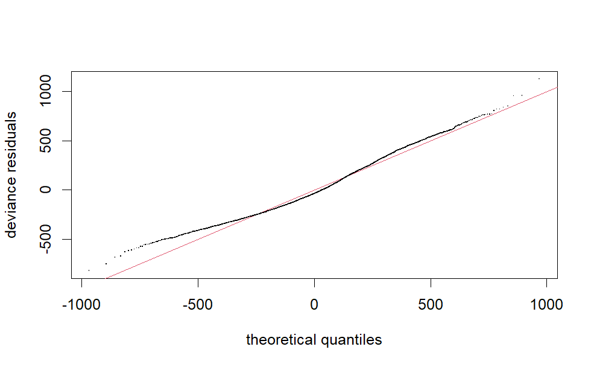

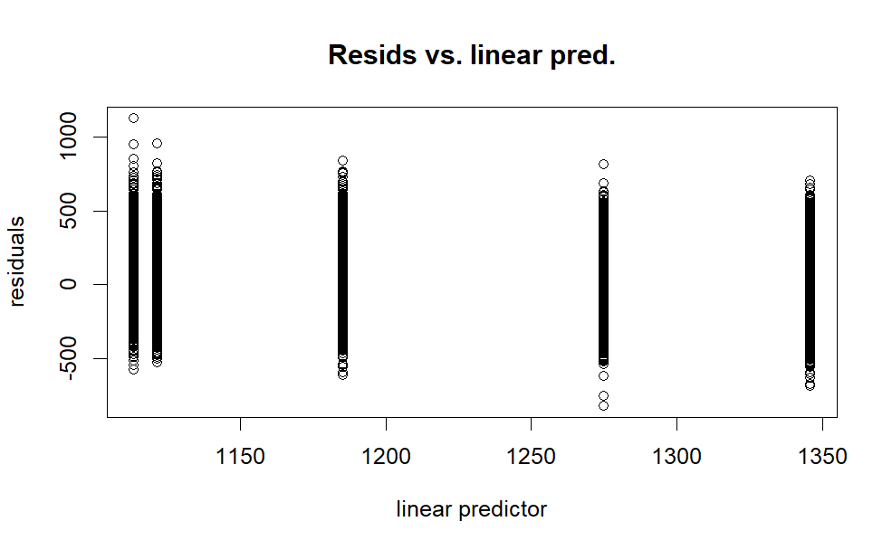

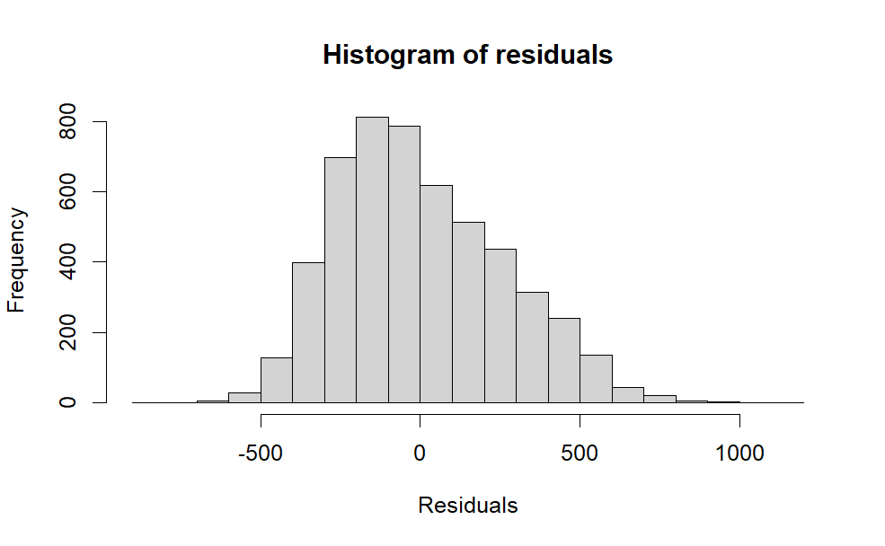

```
Method: fREML   Optimizer: perf newton
full convergence after 7 iterations.
Gradient range [-7.45941e-06,4.745384e-06]
(score 36146.18 & scale 67448.27).
Hessian positive definite, eigenvalue range [0.7944929,2589].
Model rank =  4 / 4

Basis dimension (k) checking results. Low p-value (k-index<1) may
indicate that k is too low, especially if edf is close to k'.

             k'  edf k-index p-value
s(percent) 3.00 2.84    1.01    0.79
```

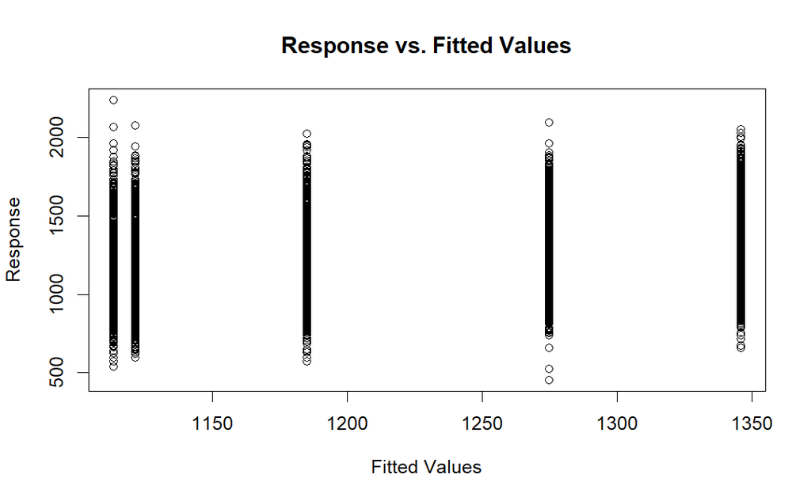

```r
gam.check(F2.gamm1)
```

```r
summary(F2.gamm1)
```

```
Family: gaussian
Link function: identity

Formula:
F2 ~ s(percent, k = 4)

Parametric coefficients:
            Estimate Std. Error t value Pr(>|t|)
(Intercept) 1208.129      3.608   334.8   <2e-16 ***
---
Signif. codes:  0 ‘***’ 0.001 ‘**’ 0.01 ‘*’ 0.05 ‘.’ 0.1 ‘ ’ 1

Approximate significance of smooth terms:
             edf Ref.df     F p-value
s(percent) 2.843  2.981 209.7  <2e-16 ***
---
Signif. codes:  0 ‘***’ 0.001 ‘**’ 0.01 ‘*’ 0.05 ‘.’ 0.1 ‘ ’ 1

R-sq.(adj) =  0.107   Deviance explained = 10.8%
fREML =  36146  Scale est. = 67448     n = 5180
```

# Basic Model plus borough

```r
F2.gamm2 <- bam(F2 ~ borough_ord +
                  s(percent, k=4) +
                  s(percent, by = borough_ord, k=4)
               , data=data_gamm,method="fREML", nthreads = all_cores)
```

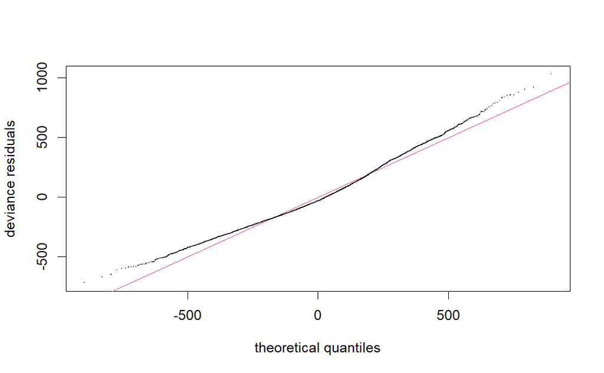

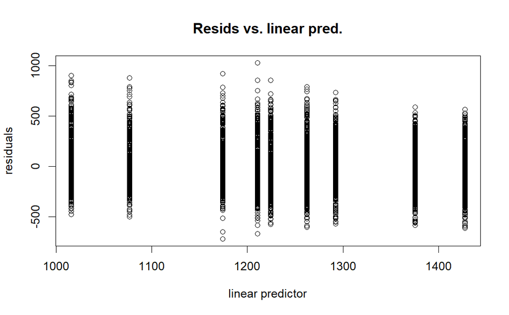

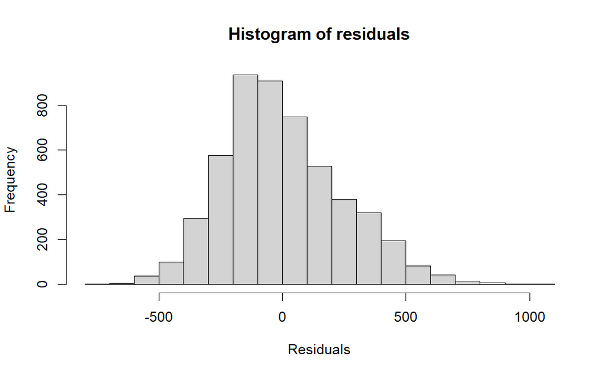

```
Method: fREML   Optimizer: perf newton
full convergence after 8 iterations.
Gradient range [-0.0003667,2.034505e-05]
(score 35735.51 & scale 57671.38).
Hessian positive definite, eigenvalue range [0.4933854,2588.001].
Model rank =  8 / 8

Basis dimension (k) checking results. Low p-value (k-index<1) may
indicate that k is too low, especially if edf is close to k'.

                                 k'  edf k-index p-value
s(percent)                     3.00 2.84       1    0.39
s(percent):borough_ordTrafford 3.00 2.20       1    0.38
```

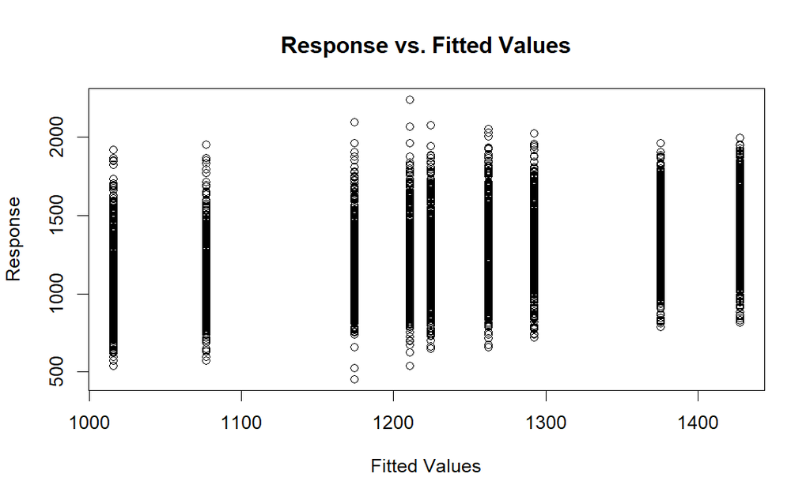

```r
gam.check(F2.gamm2)
```

```r
summary(F2.gamm2)
```

```
Family: gaussian
Link function: identity

Formula:
F2 ~ borough_ord + s(percent, k = 4) + s(percent, by = borough_ord,
    k = 4)

Parametric coefficients:
                    Estimate Std. Error t value Pr(>|t|)
(Intercept)         1109.075      4.733  234.35   <2e-16 ***
borough_ordTrafford  196.969      6.673   29.52   <2e-16 ***
---
Signif. codes:  0 ‘***’ 0.001 ‘**’ 0.01 ‘*’ 0.05 ‘.’ 0.1 ‘ ’ 1

Approximate significance of smooth terms:
                                 edf Ref.df       F p-value
s(percent)                     2.838  2.959 143.067  <2e-16 ***
s(percent):borough_ordTrafford 2.205  2.564   2.721  0.0368 *
---
Signif. codes:  0 ‘***’ 0.001 ‘**’ 0.01 ‘*’ 0.05 ‘.’ 0.1 ‘ ’ 1

R-sq.(adj) =  0.237   Deviance explained = 23.7%
fREML =  35736  Scale est. = 57671     n = 5180
```

## Interpreting the model

### Get predicted values

This set of code outputs a data frame with calculated values from your model. You can then use this to plot the model. If you are building a model which takes a while to run I recommend saving this data out to a csv so you don’t have to keep rerunning the model.

```r
F2.gamm2.p <- tidymv::predict_gam(F2.gamm2)
# write_csv(F2.gamm2.p,"../data/F2-gamm2-p.csv")
```

### Plotting the model

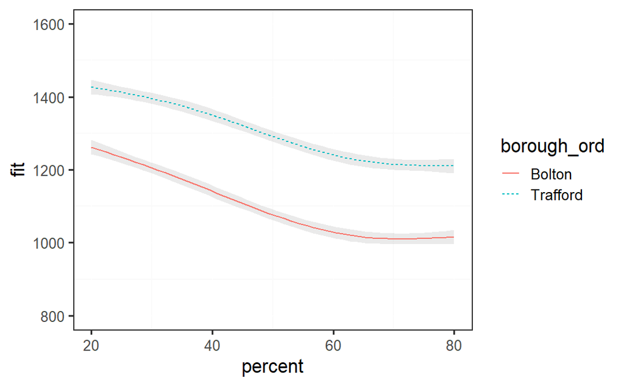

```r
F2.gamm2.plot <- ggplot(data = F2.gamm2.p,
                        aes(
                          x=percent,
                          y=fit,
                          linecolour = borough_ord
                          ))+
  theme_Caitlin_gamm()+
  geom_smooth_ci(borough_ord)+
  scale_y_continuous(position = "left",
                  limits = c(800,1600),
                  breaks = seq(0, 2000, 200)
                  )+
  NULL
F2.gamm2.plot
```

## Basic Model plus borough - with speaker random smooths

```r
F2.gamm3 <- bam(F2 ~ borough_ord +
                  s(percent, k=4) +
                  s(percent, by = borough_ord, k=4) +
                  s(percent, ID, bs="fs", xt="cr",m=1,k=4) #random smooth
               , data=data_gamm,method="fREML", nthreads = all_cores)
```

```
Warning in gam.side(sm, X, tol = .Machine$double.eps^0.5) :
  model has repeated 1-d smooths of same variable.
```

Don’t worry about the warning here - it’s because s(x) and s(x, f, bs = “fs”) are both seen as 1D smooths of x. Normally that would be a *big* problem, but the “fs” basis is fully penalized, meaning if necessary the entire set of smooths can be shrunk out of the model.

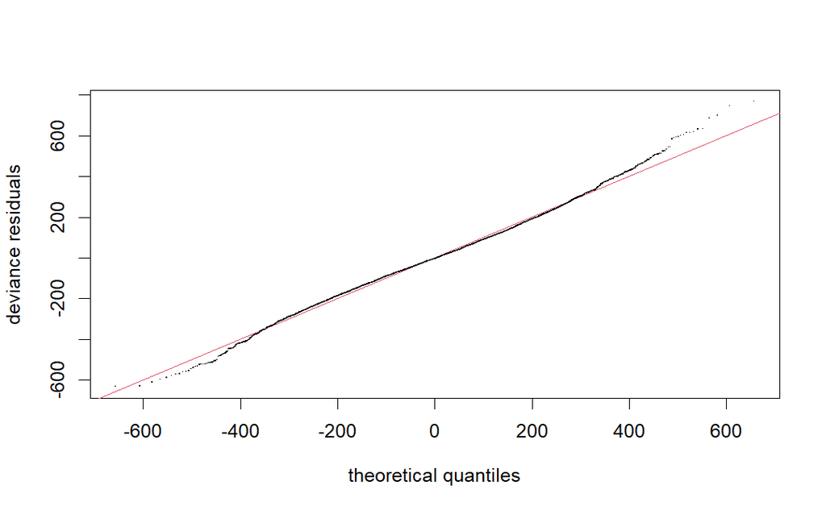

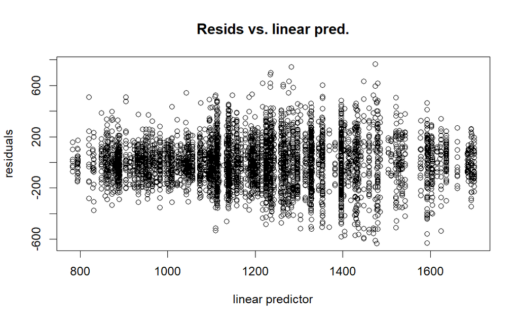

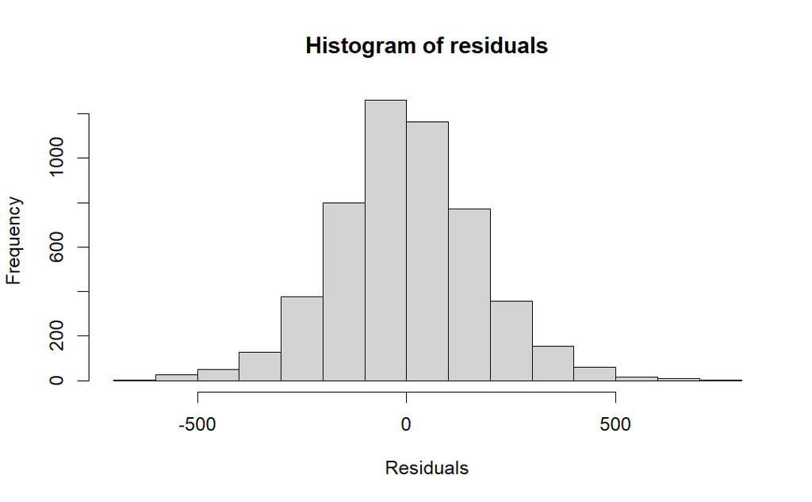

```
Method: fREML   Optimizer: perf newton
full convergence after 9 iterations.
Gradient range [-9.907904e-05,0.0002151899]
(score 34298.03 & scale 31078.15).
Hessian positive definite, eigenvalue range [0.2610668,2588.358].
Model rank =  196 / 196

Basis dimension (k) checking results. Low p-value (k-index<1) may
indicate that k is too low, especially if edf is close to k'.

                                   k'    edf k-index p-value
s(percent)                       3.00   2.90    1.04       1
s(percent):borough_ordTrafford   3.00   2.45    1.04       1
s(percent,ID)                  188.00  89.00    1.04       1
```

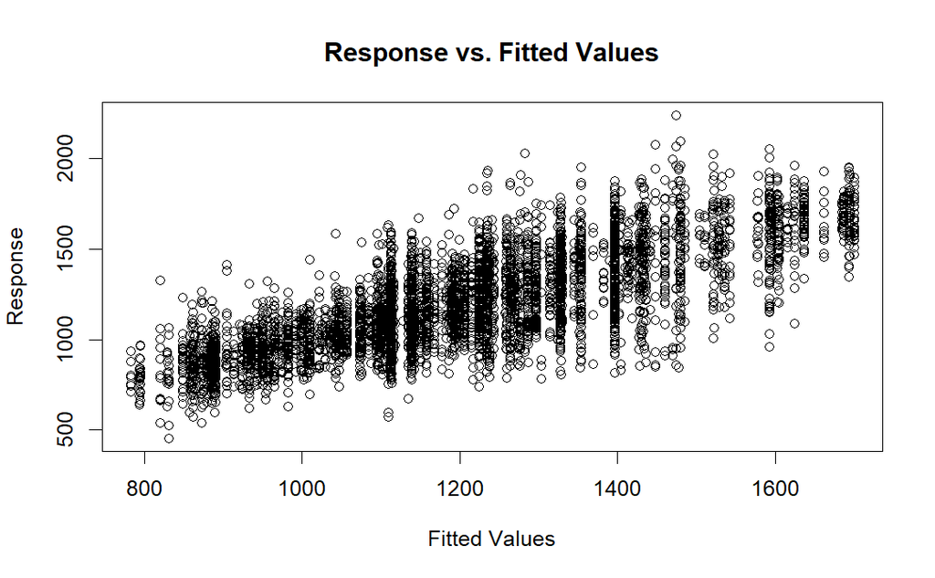

```r
gam.check(F2.gamm3)
```

```r
summary(F2.gamm3)
```

```
Family: gaussian
Link function: identity

Formula:
F2 ~ borough_ord + s(percent, k = 4) + s(percent, by = borough_ord,
    k = 4) + s(percent, ID, bs = "fs", xt = "cr", m = 1, k = 4)

Parametric coefficients:
                    Estimate Std. Error t value Pr(>|t|)
(Intercept)          1080.92      26.31  41.086  < 2e-16 ***
borough_ordTrafford   257.47      38.82   6.633 3.64e-11 ***
---
Signif. codes:  0 ‘***’ 0.001 ‘**’ 0.01 ‘*’ 0.05 ‘.’ 0.1 ‘ ’ 1

Approximate significance of smooth terms:
                                  edf  Ref.df      F p-value
s(percent)                      2.898   2.977 29.400 < 2e-16 ***
s(percent):borough_ordTrafford  2.446   2.756  3.619 0.00981 **
s(percent,ID)                  89.002 184.000 24.054 < 2e-16 ***
---
Signif. codes:  0 ‘***’ 0.001 ‘**’ 0.01 ‘*’ 0.05 ‘.’ 0.1 ‘ ’ 1

R-sq.(adj) =  0.589   Deviance explained = 59.6%
fREML =  34298  Scale est. = 31078     n = 5180
```

```r
compareML(F2.gamm2,F2.gamm3)
```

```
F2.gamm2: F2 ~ borough_ord + s(percent, k = 4) + s(percent, by = borough_ord,
    k = 4)

F2.gamm3: F2 ~ borough_ord + s(percent, k = 4) + s(percent, by = borough_ord,
    k = 4) + s(percent, ID, bs = "fs", xt = "cr", m = 1, k = 4)

Chi-square test of fREML scores
-----
```

| Model | Score | Edf | Difference | Df | p.value | Sig. |
| --- | --- | --- | --- | --- | --- | --- |
| F2.gamm2 | 35735.51 | 6 |  |  |  |  |
| F2.gamm3 | 34298.03 | 9 | 1437.480 | 3.000 | < 2e-16 | *** |

```
AIC difference: 3111.44, model F2.gamm3 has lower AIC.
```

Adding the random effects improves the model fit. Let’s add word as well.

## Basic Model plus borough - with speaker and word random smooths

```r
F2.gamm4 <- bam(F2 ~ borough_ord +
                  s(percent, k=4) +
                  s(percent, by = borough_ord, k=4) +
                  s(percent, ID, bs="fs", xt="cr",m=1,k=4) + #random smooth
                s(percent, word, bs="fs", xt="cr",m=1,k=4) #random smooth
               , data=data_gamm,method="fREML", nthreads = all_cores)
```

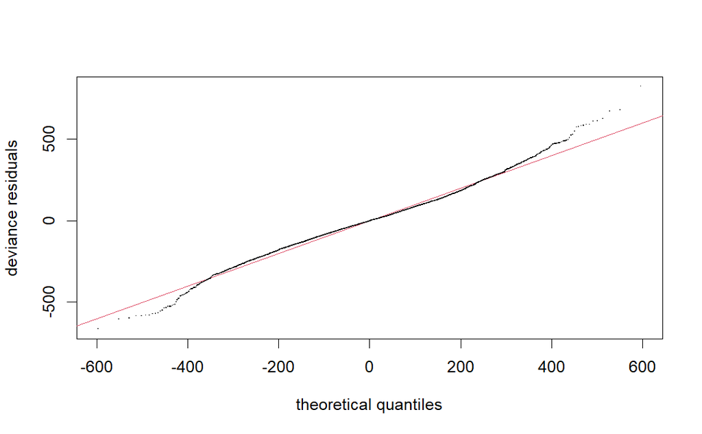

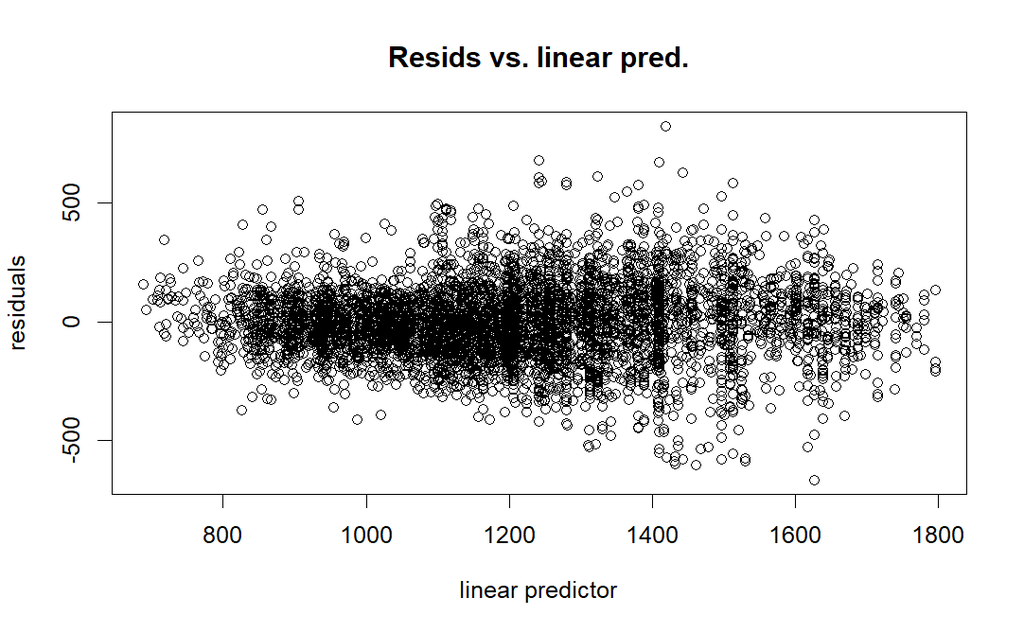

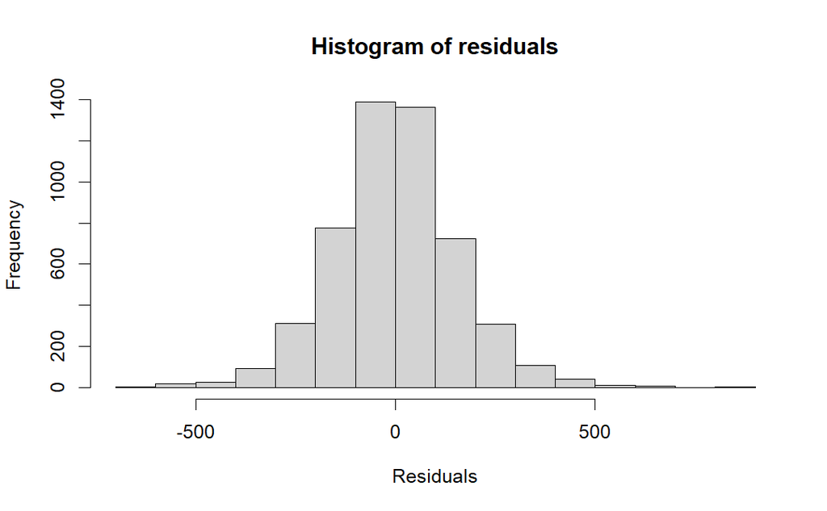

```
Method: fREML   Optimizer: perf newton
full convergence after 8 iterations.
Gradient range [-1.586961e-06,4.09099e-06]
(score 33962.27 & scale 25597.76).
Hessian positive definite, eigenvalue range [0.2223693,2589.286].
Model rank =  584 / 584

Basis dimension (k) checking results. Low p-value (k-index<1) may
indicate that k is too low, especially if edf is close to k'.

                                   k'    edf k-index p-value
s(percent)                       3.00   2.88    1.02    0.94
s(percent):borough_ordTrafford   3.00   2.52    1.02    0.94
s(percent,ID)                  188.00  89.40    1.02    0.90
s(percent,word)                388.00 150.14    1.02    0.90
```

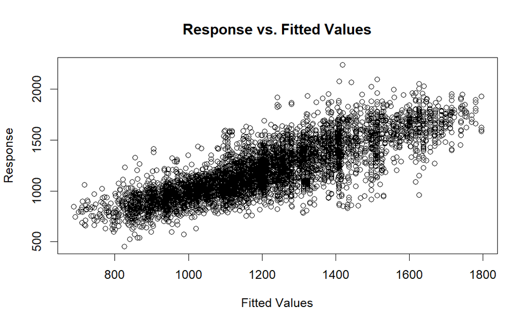

```r
gam.check(F2.gamm4)
```

```r
summary(F2.gamm4)
```

```
Family: gaussian
Link function: identity

Formula:
F2 ~ borough_ord + s(percent, k = 4) + s(percent, by = borough_ord,
    k = 4) + s(percent, ID, bs = "fs", xt = "cr", m = 1, k = 4) +
    s(percent, word, bs = "fs", xt = "cr", m = 1, k = 4)

Parametric coefficients:
                    Estimate Std. Error t value Pr(>|t|)
(Intercept)          1047.63      27.79  37.698  < 2e-16 ***
borough_ordTrafford   267.80      39.00   6.866 7.42e-12 ***
---
Signif. codes:  0 ‘***’ 0.001 ‘**’ 0.01 ‘*’ 0.05 ‘.’ 0.1 ‘ ’ 1

Approximate significance of smooth terms:
                                   edf  Ref.df      F p-value
s(percent)                       2.882   2.961 20.550 < 2e-16 ***
s(percent):borough_ordTrafford   2.521   2.807  4.355 0.00354 **
s(percent,ID)                   89.404 184.000 26.042 < 2e-16 ***
s(percent,word)                150.138 386.000  2.818 < 2e-16 ***
---
Signif. codes:  0 ‘***’ 0.001 ‘**’ 0.01 ‘*’ 0.05 ‘.’ 0.1 ‘ ’ 1

R-sq.(adj) =  0.661   Deviance explained = 67.7%
fREML =  33962  Scale est. = 25598     n = 5180
```

```r
compareML(F2.gamm3,F2.gamm4)
```

```
F2.gamm3: F2 ~ borough_ord + s(percent, k = 4) + s(percent, by = borough_ord,
    k = 4) + s(percent, ID, bs = "fs", xt = "cr", m = 1, k = 4)

F2.gamm4: F2 ~ borough_ord + s(percent, k = 4) + s(percent, by = borough_ord,
    k = 4) + s(percent, ID, bs = "fs", xt = "cr", m = 1, k = 4) +
    s(percent, word, bs = "fs", xt = "cr", m = 1, k = 4)

Chi-square test of fREML scores
-----
```

| Model | Score | Edf | Difference | Df | p.value | Sig. |
| --- | --- | --- | --- | --- | --- | --- |
| F2.gamm3 | 34298.03 | 9 |  |  |  |  |
| F2.gamm4 | 33962.27 | 12 | 335.764 | 3.000 | < 2e-16 | *** |

```
AIC difference: 855.95, model F2.gamm4 has lower AIC.
```

Adding word also improves the model fit. Let’s get the predictions and look at the plot. For fitting and interpreting the model we’re not interested in the random effects so we exclude them from the model predictions.

```r
F2.gamm4.p <- tidymv::predict_gam(F2.gamm4,
                                  exclude_terms = list(
                            "s(percent,ID)"
                            ,"s(percent,word)"
                          ),
                          values = list(
                            ID = NULL
                            ,word = NULL
                          )
                          )
# write_csv(F2.gamm4.p,"../data/F2-gamm4-p.csv")
```

### Plotting the model

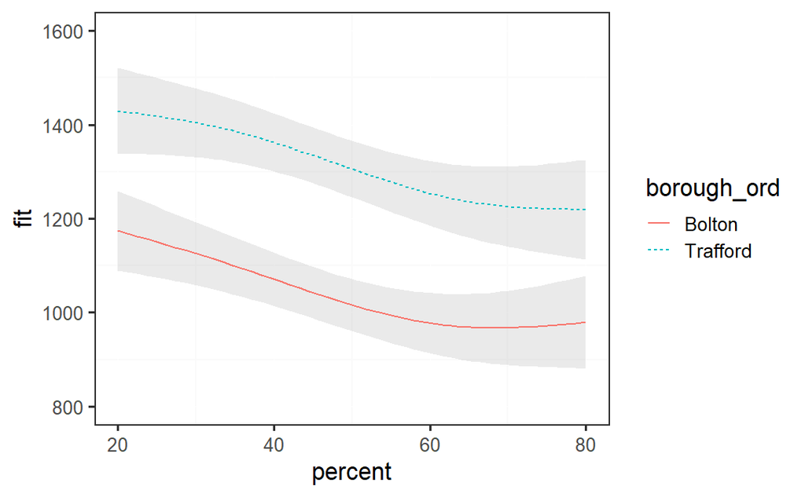

```r
F2.gamm4.plot <- ggplot(data = F2.gamm4.p,
                        aes(
                          x=percent,
                          y=fit,
                          linecolour = borough_ord
                          ))+
  theme_Caitlin_gamm()+
  geom_smooth_ci(borough_ord)+
  scale_y_continuous(position = "left",
                  limits = c(800,1600),
                  breaks = seq(0, 2000, 200)
                  )+
  NULL
F2.gamm4.plot
```

There’s two more types of term I want to add. The first is called a tensor product interaction - duration may have an effect on the shapes of the trajectories so we want a non-linear interaction between duration and the smooths for (Soskuthy, 2017, p. 25). The second is a term to tie together the individual trajectories. The latter is the one that usually causes computer size/speed problems.

```r
F2.gamm5 <- bam(F2 ~ borough_ord +
                  s(percent, k=4) +
                  s(percent, by = borough_ord, k=4) +
                  ti(percent, dur) + #interaction between shape and duration
                  s(percent, ID, bs="fs", xt="cr",m=1,k=4) + #random smooth
                  s(percent, word, bs="fs", xt="cr",m=1,k=4) + #random smooth
                # s(percent, traj, bs="fs", xt="cr",m=1,k=4) #random smooth
                  s(traj, bs="re") + #random intercept
                  s(traj, percent, bs="re") # random slope
               , data=data_gamm,method="fREML", nthreads = all_cores)
```

```r
compareML(F2.gamm4,F2.gamm5)
```

```
F2.gamm4: F2 ~ borough_ord + s(percent, k = 4) + s(percent, by = borough_ord,
    k = 4) + s(percent, ID, bs = "fs", xt = "cr", m = 1, k = 4) +
    s(percent, word, bs = "fs", xt = "cr", m = 1, k = 4)

F2.gamm5: F2 ~ borough_ord + s(percent, k = 4) + s(percent, by = borough_ord,
    k = 4) + ti(percent, dur) + s(percent, ID, bs = "fs", xt = "cr",
    m = 1, k = 4) + s(percent, word, bs = "fs", xt = "cr", m = 1,
    k = 4) + s(traj, bs = "re") + s(traj, percent, bs = "re")

Chi-square test of fREML scores
-----
```

| Model | Score | Edf | Difference | Df | p.value | Sig. |
| --- | --- | --- | --- | --- | --- | --- |
| F2.gamm4 | 33962.27 | 12 |  |  |  |  |
| F2.gamm5 | 33929.68 | 17 | 32.588 | 5.000 | 1.030e-12 | *** |

```
AIC difference: 60.46, model F2.gamm5 has lower AIC.
```

After this it’s just a case of adding more predictors as relevant for your data. I would usually add these one at a time and use the compareML() function to see if they’re improving the model fit. We’ll skip a few steps and jump to a more complicated model to look at interpretation.

# Final GAMM

```r
F2.gamm9 <- bam(F2 ~ borough_ord +
                  ageGroup_ord +
                  folSeg_ord +
                  style_med_ord +
                  s(percent, k=4) +
                  s(percent, by = borough_ord, k=4) +
                  s(percent, by = ageGroup_ord, k=4) +
                  s(percent, by = folSeg_ord, k=4) +
                  s(percent, by = style_med_ord, k=4) +
                  ti(percent, dur) + #interaction between shape and duration
                  s(percent, ID, bs="fs", xt="cr",m=1,k=4) + #random smooth
                  s(percent, word, bs="fs", xt="cr",m=1,k=4) + #random smooth
                # s(percent, traj, bs="fs", xt="cr",m=1,k=4) #random smooth
                  s(traj, bs="re") + #random intercept
                  s(traj, percent, bs="re") # random slope
               , data=data_gamm,method="fREML", nthreads = all_cores)
```

```r
summary(F2.gamm9)
```

```
Family: gaussian
Link function: identity

Formula:
F2 ~ borough_ord + ageGroup_ord + folSeg_ord + style_med_ord +
    s(percent, k = 4) + s(percent, by = borough_ord, k = 4) +
    s(percent, by = ageGroup_ord, k = 4) + s(percent, by = folSeg_ord,
    k = 4) + s(percent, by = style_med_ord, k = 4) + ti(percent,
    dur) + s(percent, ID, bs = "fs", xt = "cr", m = 1, k = 4) +
    s(percent, word, bs = "fs", xt = "cr", m = 1, k = 4) + s(traj,
    bs = "re") + s(traj, percent, bs = "re")

Parametric coefficients:
                                   Estimate Std. Error t value Pr(>|t|)
(Intercept)                         1088.95      59.59  18.274  < 2e-16
borough_ordTrafford                  241.36      40.77   5.920 3.44e-09
ageGroup_ord26-45                   -187.12      63.22  -2.960  0.00309
ageGroup_ord46-65                   -125.14      60.28  -2.076  0.03794
ageGroup_ord66+                     -222.11      71.05  -3.126  0.00178
folSeg_ordnonlateral                  95.96      24.53   3.911 9.30e-05
style_med_ordvaninterview.inperson    16.74      14.31   1.170  0.24224
style_med_ordmap.online               82.78      41.06   2.016  0.04383
style_med_ordvaninterview.online     -11.91      12.29  -0.969  0.33254

(Intercept)                        ***
borough_ordTrafford                ***
ageGroup_ord26-45                  **
ageGroup_ord46-65                  *
ageGroup_ord66+                    **
folSeg_ordnonlateral               ***
style_med_ordvaninterview.inperson
style_med_ordmap.online            *
style_med_ordvaninterview.online
---
Signif. codes:  0 ‘***’ 0.001 ‘**’ 0.01 ‘*’ 0.05 ‘.’ 0.1 ‘ ’ 1

Approximate significance of smooth terms:
                                                    edf  Ref.df      F
s(percent)                                    2.865e+00   2.949 15.207
s(percent):borough_ordTrafford                2.388e+00   2.714  2.771
```

[output cut: 17 more lines]

```
s(percent):ageGroup_ord66+                      0.0372 *
s(percent):folSeg_ordnonlateral                 0.0285 *
s(percent):style_med_ordvaninterview.inperson   0.1711
s(percent):style_med_ordmap.online              0.9226
s(percent):style_med_ordvaninterview.online     0.0577 .
ti(percent,dur)                                < 2e-16 ***
s(percent,ID)                                  < 2e-16 ***
s(percent,word)                                < 2e-16 ***
s(traj)                                         0.6648
s(traj,percent)                                 0.2152
---
Signif. codes:  0 ‘***’ 0.001 ‘**’ 0.01 ‘*’ 0.05 ‘.’ 0.1 ‘ ’ 1

R-sq.(adj) =  0.666   Deviance explained = 68.2%
fREML =  33844  Scale est. = 25223     n = 5180
```

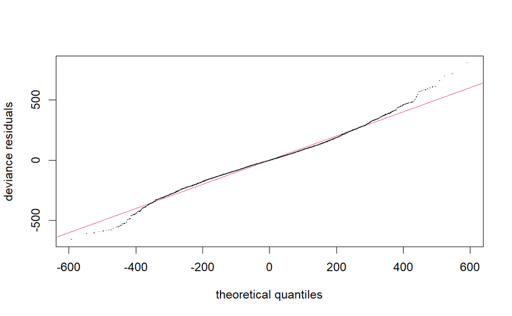

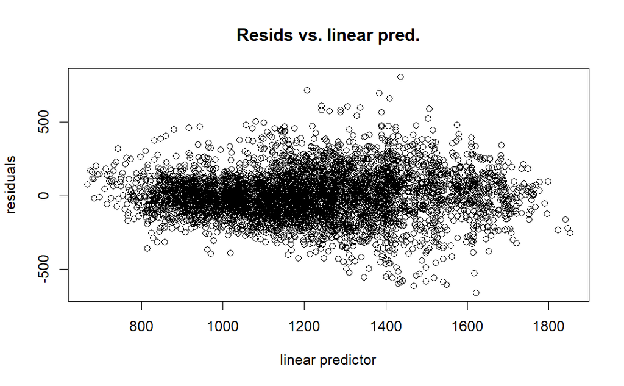

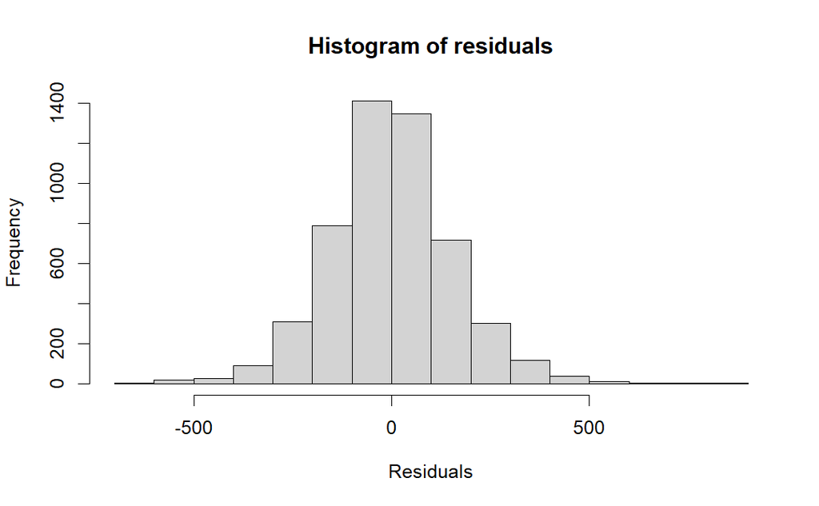

```
Method: fREML   Optimizer: perf newton
full convergence after 14 iterations.
Gradient range [-6.006766e-05,0.0001301414]
(score 33843.75 & scale 25222.6).
eigenvalue range [-3.571363e-06,2581.636].
Model rank =  630 / 630

Basis dimension (k) checking results. Low p-value (k-index<1) may
indicate that k is too low, especially if edf is close to k'.

                                                    k'      edf k-index
s(percent)                                    3.00e+00 2.87e+00    1.00
s(percent):borough_ordTrafford                3.00e+00 2.39e+00    1.00
s(percent):ageGroup_ord26-45                  3.00e+00 1.00e+00    1.00
s(percent):ageGroup_ord46-65                  3.00e+00 1.00e+00    1.00
s(percent):ageGroup_ord66+                    3.00e+00 2.27e+00    1.00
s(percent):folSeg_ordnonlateral               3.00e+00 1.00e+00    1.00
s(percent):style_med_ordvaninterview.inperson 3.00e+00 1.00e+00    1.00
s(percent):style_med_ordmap.online            3.00e+00 1.12e+00    1.00
s(percent):style_med_ordvaninterview.online   3.00e+00 1.00e+00    1.00
ti(percent,dur)                               1.60e+01 6.60e+00    0.95
s(percent,ID)                                 1.88e+02 7.87e+01    1.00
s(percent,word)                               3.88e+02 1.45e+02    1.00
s(traj)                                       1.00e+00 8.48e-05    0.55
s(traj,percent)                               1.00e+00 2.11e-05    0.66
                                              p-value
s(percent)                                       0.38
s(percent):borough_ordTrafford                   0.38
s(percent):ageGroup_ord26-45                     0.28
s(percent):ageGroup_ord46-65                     0.34
s(percent):ageGroup_ord66+                       0.41
s(percent):folSeg_ordnonlateral                  0.33
s(percent):style_med_ordvaninterview.inperson    0.36
s(percent):style_med_ordmap.online               0.38
s(percent):style_med_ordvaninterview.online      0.38
ti(percent,dur)                                <2e-16 ***
s(percent,ID)                                    0.38
s(percent,word)                                  0.42
s(traj)                                        <2e-16 ***
s(traj,percent)                                <2e-16 ***
---
Signif. codes:  0 ‘***’ 0.001 ‘**’ 0.01 ‘*’ 0.05 ‘.’ 0.1 ‘ ’ 1
```

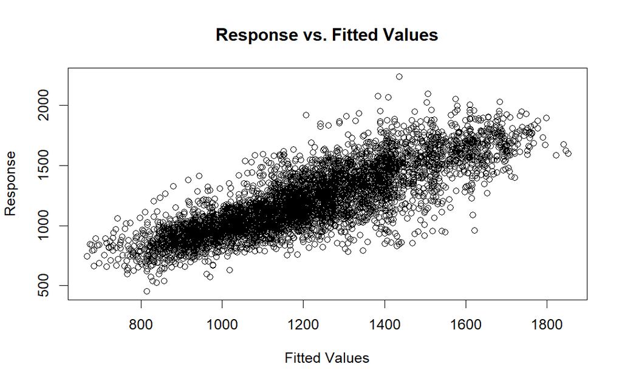

```r
gam.check(F2.gamm9)
```

As before we can extract the predictions:

```r
F2.gamm9.p <- tidymv::predict_gam(F2.gamm9,
                                  exclude_terms = list(
                            "s(percent:ageGroup_ord"
                            ,"s(percent:style_med_ord"
                            ,"s(percent,ID)"
                            ,"s(percent,word)"
                            ,"ti(percent,dur)"
                            ,"s(traj)"
                            ,"s(traj,percent"
                          ),
                          values = list(
                            ageGroup_ord = NULL
                            ,style_med_ord = NULL
                            ,ID = NULL
                            ,word = NULL
                            ,dur = mean(data_gamm$dur)
                            ,traj = NULL
                          )
                          )
# write_csv(F2.gamm9.p,"../data/F2-gamm9-p.csv")
```

Then plot the predicted values.

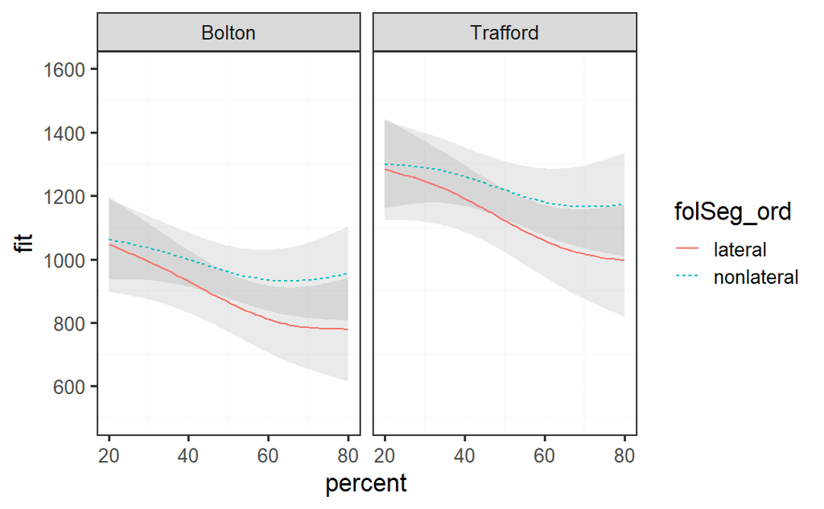

```r
F2.gamm9.plot <- ggplot(data = F2.gamm9.p,
                        aes(
                          x=percent,
                          y=fit,
                          linecolour = folSeg_ord
                          ))+
  theme_Caitlin_gamm()+
  geom_smooth_ci(folSeg_ord)+
  scale_y_continuous(position = "left",
                  limits = c(500,1600),
                  breaks = seq(0, 2000, 200)
                  )+
  facet_wrap(~borough_ord)+
  NULL
F2.gamm9.plot
```